# Introduction to R and RStudio

## Motivation

Science is a multi-step process: once you’ve designed an experiment and collected data, the real fun begins! This lesson will teach you how to start this process using R and RStudio. We will begin with raw data, perform exploratory analyses, and learn how to plot results graphically. This example starts with a dataset from gapminder.org containing population information for many countries through time. Can you read the data into R? Can you plot the population for Senegal? Can you calculate the average income for countries on the continent of Asia? By the end of these lessons you will be able to do things like plot the populations for all of these countries in under a minute!

## Before Starting The Workshop

Please ensure you have the latest version of R, RStudio, and Quarto installed on your machine, or that you are set up with Posit cloud (in which case everything will be installed for you). If you are having trouble installing any of the software on your local machine, we recommend that you use the Posit cloud instance that we have set up.

Note that if you are working locally, we recommend re-installing R, RStudio, and Quarto to ensure that you have the latest version, as some features and packages used in the workshop may not work correctly (or at all) if your R, RStudio, and quarto are not up to date.

- [Download and install the latest version of R here](https://www.r-project.org/)
- [Download and install RStudio here](https://posit.co/download/rstudio-desktop/#download)
- [Download and install Quarto here](https://quarto.org/docs/get-started/)

## Introduction to RStudio

Throughout this lesson, we’re going to teach you some of the fundamentals of the R language as well as some best practices for organizing code for scientific projects that will make your life easier.

We’ll be using RStudio: a free, open-source R Integrated Development Environment (IDE). It provides a built-in editor, works on all platforms (including on servers) and provides many advantages such as integration with version control and project management.

**Basic layout**

When you first open RStudio, you will be greeted by three panels:

- The interactive R console/Terminal (entire left)
- Environment/History/Connections (tabbed in upper right)
- Files/Plots/Packages/Help/Viewer (tabbed in lower right)

[figure not shown]

RStudio layout

Once you open files, such as R scripts or quarto documents, an editor panel will also open in the top left.

[figure not shown]

RStudio layout with .R file open

## *Quarto documents*

**Quarto documents**

In this workshop, we will be saving our code in “quarto” documents (formerly R markdown documents). Quarto documents let us combine text, code, and output (such as plots and tables) into an html or pdf file. Quarto files have `.qmd` at the end of their names.

Quarto documents (like their predecessor, R Markdown documents) allow you to combine text and code, so that rather than having your code standing alone in its own file, your code and its output can instead lie nestled in between narrative text that describes the analysis that you’re conducting and summarizes the results. Quarto documents are mind-blowingly versatile, and while they are mostly used to create simple html or pdf documents, they can also be used to make websites, blog posts, and books!

Since we want to practice *reproducible* data science, it is important that we keep detailed records of the code that we wrote which led us to our data-driven answers. Quarto provides us with an easy way of doing that, plus since you can surround your code with text narrative, it can be used to communicate your analysis and results to other people: Quarto lets us feed two birds with one seed!

To start a new quarto document:

[figure not shown]

- Choose a title (e.g., “My first quarto document”), and make yourself the author.
- Select the HTML output option.
- Select the “knitr” engine from the drop-down menu.
- Un-check “Use visual markdown editor” (if it is checked).
- Hit the “*Create*” button to create your file.

This will open up a new quarto template document in the documents panel:

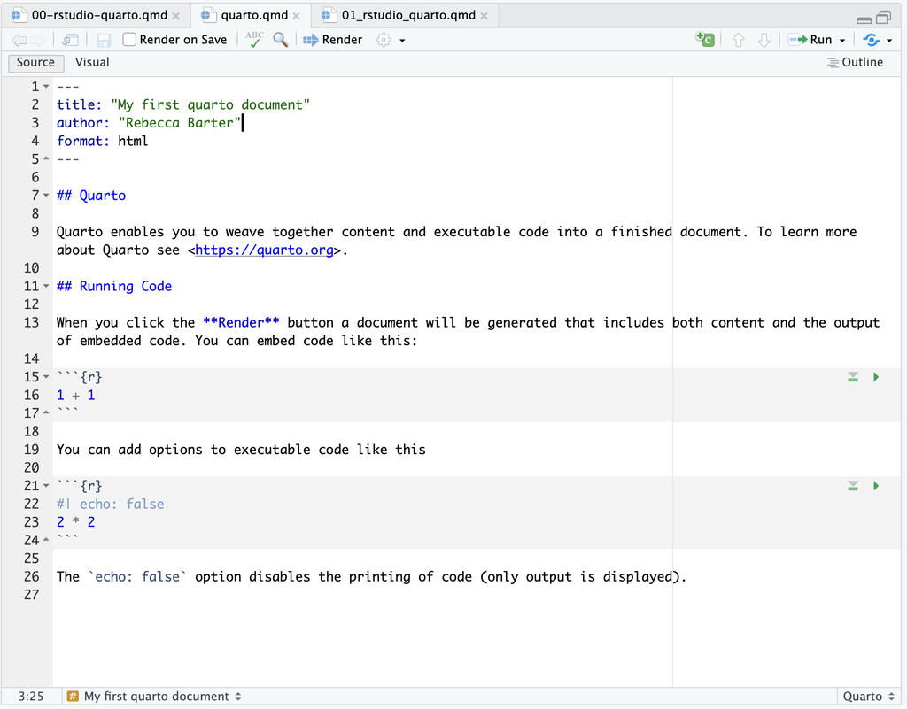

### Rendering quarto documents

The quarto file that you’ve just created contains a very brief summary of how quarto documents work. Note the instructions “*When you click the **Render** button a document will be generated that includes both content and the output of embedded code*.”

If you hit “Render” button while your quarto document is open, you should see that some code appeared very quickly in your console panel and your web browser opened up with a new (html) webpage titled “*My first quarto document*” that looks like this:

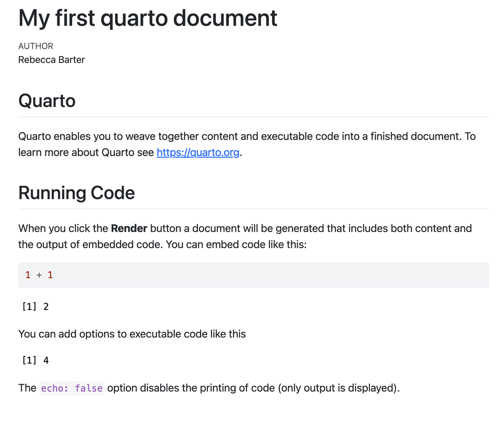

If you’re using RStudio in the cloud (or you have different settings to me), you may have instead found that the window opened in the “Viewer” panel of your RStudio application. If no window opened anywhere, find the `analysis.html` file on your computer that was created when you hit “Render”, and open it in your web browser.

Hitting the “Render” button “renders” your *interactive* quarto (.qmd) document as a *static* html (.html) file. This is like saving your interactive word document file as a static pdf file. Compare the original quarto (`.qmd`) document with the rendered web-browser page (`.html`). If you’re viewing the `.qmd` file in visual mode, they should look fairly similar.

**Simplifying quarto files**

When you compile quarto document, you will find that a number of superfluous files are created in a `xx_files/` folder, and this folder is required for the .html output to be rendered properly (i.e., the formatting in the .html file will be lost if you separate the .html output file from the `xx_files/` folder).

You can fix this by “embedding” these resource files inside the rendered html output document by specifying `embed-resources: true` in the “yaml” (document settings) at the top of the quarto document.

```
---
title: "Introduction to R and RStudio"
output: html
embed-resources: true
---
```

With this option, the `xx_files/` folder will no longer be created and the html file will be properly rendered as a stand-alone file.

#### Markdown text

Based on the html output, let’s try to make some sense of the syntax used in the original quarto (.qmd) document. The text in a quarto document uses *markdown* syntax.

Can you figure out what the `##` syntax does (if you can’t see the `##` syntax, ensure that you are viewing the quarto document using “Source” rather than “Visual” in the top-right corner of the document)? The pound symbols are **markdown** syntax for creating headers: `#` will create a top-level header, `##` will create a level-2 header, `###` will create a level-3 header, etc.

Notice that the word “**Render**” is shown in bold in the rendered html file. By looking at the .qmd file, can you figure out what the markdown syntax is for creating bold-face text?

To learn more about markdown syntax, see https://www.markdownguide.org/basic-syntax/.

## Writing code in quarto documents

### Code chunks

At this stage, much of quarto’s power (like its predecessor, R Markdown) lies in combining text with “**code chunks**”. Take a look at your analysis.qmd file. This file already contains two code chunks indicated by the following syntax:

````markdown
```{r}

```
````

`` ```{r} `` tells quarto that you’re beginning an R “code chunk”, i.e., you’re about to write some R code, and `` ``` `` tells quarto that you’re done with R and are going back to writing regular (markdown) text.

Note in the compiled markdown document, this R code chunk rendered as:

```r
1 + 1
```

```
[1] 2
```

In the rendered html file, the output (`[1] 2`) of the R code being evaluated (`1 + 1`) is shown below the code itself (note also that while the code is shown in the html output, the backtick syntax is hidden).

Why is there a `[1]` before the output (`[1] 2`)? This is just specifying that `2` is the first “entry” of the output.

Note that in the second code chunk, there is a “code chunk option” specified: `#| echo: false` .

````markdown
```{r}
#| echo: false
2 * 2
```
````

This `#|` syntax at the beginning of a code chunk corresponds to various options for when the code chunk is “rendered” into html (or pdf).

By looking at the output html file, can you figure out what `#| echo: false` does?

It hides the code from the html output file, while still showing the output (`[1] 4`). Sometimes, depending on the type of document you’re creating and who your intended audience is, it is often helpful to hide the code, but still show the output (e.g., figures or tables) of your R code in the document.

### Code comments

Note that another use of the `#` symbol in an R code chunk is as a **code comment** (in this case, `#` will not be followed by `|`). Code comments will be shown with your code chunk but don’t do anything other than add some text alongside your code, which is often helpful for explaining what a piece of code is doing when it’s not obvious.

[output not shown]

## The console

Rather than compiling your quarto document every time you want to look at the output of the code in your quarto document, you can instead run individual chunks of your code in the R console.

**Tip: Running segments of your code in the console**

RStudio offers you great flexibility in running code from within the editor window. There are buttons, menu choices, and keyboard shortcuts. To run the current line of code inside a code chunk, you can 1. click on the `Run` button above the editor panel, or 2. select “Run Lines” from the “Code” menu, or 3. hit `Ctrl`+`Return` in Windows or Linux or `⌘`+`Return` on OS X. (This shortcut can also be seen by hovering the mouse over the button).

The first thing you will see in the R console (interactive session) is a bunch of information, followed by a “>” and a blinking cursor. In many ways this is similar to the shell environment you learned about during the shell lessons: it operates on the same idea of a “Read, evaluate, print loop”: you type in commands, R tries to execute them, and then returns a result.

If you type in an incomplete command, R will wait for you to complete it. If you are familiar with Unix Shell’s bash, you may recognize this  
behavior from bash.

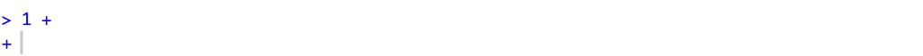

Any time you hit return and the R session shows a “+” instead of a “>”, it means it’s waiting for you to complete the command. If you want to cancel a command you can hit `Esc` and RStudio will give you back the “>” prompt.

**Tip: Canceling commands**

If you’re using R from the command line instead of from within RStudio, you need to use `Ctrl`+`C` instead of `Esc` to cancel the command. This applies to Mac users as well! Canceling a command isn’t only useful for killing incomplete commands: you can also use it to tell R to stop running code (for example if it’s taking much longer than you expect), or to get rid of the code you’re currently writing.

## Using R as a calculator

When using R as a calculator, the order of operations is the same as you would have learned back in school.

From highest to lowest precedence:

- Parentheses: `(`, `)`
- Exponents: `^` or `**`
- Multiply: `*`
- Divide: `/`
- Add: `+`
- Subtract: `-`

```r
3 + 5 * 2
```

```
[1] 13
```

Use parentheses to group operations in order to force the order of evaluation if it differs from the default, or to make clear what you intend.

```r
(3 + 5) * 2
```

```
[1] 16
```

This can get unwieldy when not needed, but clarifies your intentions. Remember that others may later read your code.

```r
(3 + (5 * (2 ^ 2))) # hard to read
3 + 5 * 2 ^ 2       # clear, if you remember the rules
3 + 5 * (2 ^ 2)     # if you forget some rules, this might help
```

The text after each line of code is called a “comment”. Anything that follows after the hash (or octothorpe) symbol `#` is ignored by R when it executes code. (Note the difference between a code comment and a chunk option specified with `|#`)

Really small or large numbers get a scientific notation:

```r
2/10000
```

```
[1] 2e-04
```

Which is shorthand for “multiplied by `10^XX`”. So `2e-4` is shorthand for `2 * 10^(-4)`.

You can write numbers in scientific notation too:

```r
5e3  # Note the lack of minus here
```

```
[1] 5000
```

## Mathematical functions

R has many built in mathematical functions. To call a function, we can type its name, followed by open and closing parentheses. Functions take arguments as inputs, anything we type inside the parentheses of a function is considered an argument. Depending on the function, the number of arguments can vary from none to multiple. For example:

```r
getwd() #returns an absolute filepath
```

doesn’t require an argument, whereas for the next set of mathematical functions we will need to supply the function a value in order to compute the result.

```r
sin(1)  # trigonometry functions
```

```
[1] 0.841471
```

```r
log(1)  # natural logarithm
```

```
[1] 0
```

```r
log10(10) # base-10 logarithm
```

```
[1] 1
```

```r
exp(0.5) # e^(1/2)
```

```
[1] 1.648721
```

Don’t worry about trying to remember every function in R. You can look them up on Google, or if you can remember the start of the function’s name, use the tab completion in RStudio.

This is one advantage that RStudio has over R on its own, it has auto-completion abilities that allow you to more easily look up functions, their arguments, and the values that they take.

Typing a `?` before the name of a command will open the help page for that command. When using RStudio, this will open the ‘Help’ pane; if using R in the terminal, the help page will open in your browser. The help page will include a detailed description of the command and how it works. Scrolling to the bottom of the help page will usually show a collection of code examples which illustrate command usage. We’ll go through an example later.

## Comparing things

We can also do comparisons in R:

```r
1 == 1  # equality (note two equals signs, read as "is equal to")
```

```
[1] TRUE
```

```r
1 != 2  # inequality (read as "is not equal to")
```

```
[1] TRUE
```

```r
1 < 2  # less than
```

```
[1] TRUE
```

```r
1 <= 1  # less than or equal to
```

```
[1] TRUE
```

```r
1 > 0  # greater than
```

```
[1] TRUE
```

```r
1 >= -9 # greater than or equal to
```

```
[1] TRUE
```

## Variables and assignment

We can store values in variables using the assignment operator `<-`, like this:

```r
x <- 1/40
```

Notice that assignment does not print a value. Instead, we stored it for later in something called a **variable**. `x` now contains the **value** `0.025`:

```r
x
```

```
[1] 0.025
```

Look for the `Environment` tab in the top right panel of RStudio, and you will see that `x` and its value have appeared. Our variable `x` can be used in place of a number in any calculation that expects a number:

```r
log(x)
```

```
[1] -3.688879
```

Notice also that variables can be reassigned:

```r
x <- 100
```

`x` used to contain the value 0.025 and now it has the value 100.

Assignment values can contain the variable being assigned to:

```r
x <- x + 1 #notice how RStudio updates its description of x on the top right tab
y <- x * 2
```

The right hand side of the assignment can be any valid R expression. The right hand side is *fully evaluated* before the assignment occurs.

Note that it is also possible to use the `=` operator for assignment:

```r
x = 1/40
```

But this is much less common among R users and the general recommendation is to use `<-`.

**Challenge 1**

Which of the following are valid R variable names?

```r
min_height
max.height
_age
.mass
MaxLength
min-length
2widths
celsius2kelvin
```

**Solution to Challenge 1**

The following variable names are valid:

```r
min_height
max.height
MaxLength
celsius2kelvin
```

The following creates a hidden variable:

```r
.mass
```

## Vectorization

One final thing to be aware of is that R is *vectorized*, meaning that variables and functions can have vectors as values. In contrast to physics and mathematics, a vector in R describes a set of values in a certain order of the same data type. For example

```r
1:5
```

```
[1] 1 2 3 4 5
```

```r
2^(1:5)
```

```
[1]  2  4  8 16 32
```

```r
x <- 1:5
2^x
```

```
[1]  2  4  8 16 32
```

This is incredibly powerful; we will discuss this further in an upcoming lesson.

## Managing your environment

There are a few useful commands you can use to interact with the R session.

`ls` will list all of the variables and functions stored in the global environment (your working R session):

```r
ls()
```

```
[1] "x" "y"
```

Note here that we didn’t give any arguments to `ls`, but we still needed to give the parentheses to tell R to call the function.

If we type `ls` by itself, R prints a bunch of code instead of a listing of objects.

```r
ls
```

```
function (name, pos = -1L, envir = as.environment(pos), all.names = FALSE,
    pattern, sorted = TRUE)
{
    if (!missing(name)) {
        pos <- tryCatch(name, error = function(e) e)
        if (inherits(pos, "error")) {
            name <- substitute(name)
            if (!is.character(name))
                name <- deparse(name)
            warning(gettextf("%s converted to character string",
                sQuote(name)), domain = NA)
            pos <- name
        }
    }
    all.names <- .Internal(ls(envir, all.names, sorted))
    if (!missing(pattern)) {
        if ((ll <- length(grep("[", pattern, fixed = TRUE))) &&
            ll != length(grep("]", pattern, fixed = TRUE))) {
            if (pattern == "[") {
                pattern <- "\\["
                warning("replaced regular expression pattern '[' by  '\\\\['")
            }
            else if (length(grep("[^\\\\]\\[<-", pattern))) {
                pattern <- sub("\\[<-", "\\\\\\[<-", pattern)
                warning("replaced '[<-' by '\\\\[<-' in regular expression pattern")
            }
        }
        grep(pattern, all.names, value = TRUE)
    }
    else all.names
}
<bytecode: 0x111c24a48>
<environment: namespace:base>
```

What’s going on here?

Like everything in R, `ls` is the name of an object, and entering the name of an object by itself prints the contents of the object. The object `x` that we created earlier contains 1, 2, 3, 4, 5:

```r
x
```

```
[1] 1 2 3 4 5
```

The object `ls` contains the R code that makes the `ls` function work! We’ll talk more about how functions work and start writing our own later.

You can use `rm` to delete objects you no longer need:

```r
rm(x)
```

If you have lots of things in your environment and want to delete all of them, you can pass the results of `ls` to the `rm` function (or you can click the “broom” icon in the environment panel):

```r
rm(list = ls())
```

In this case we’ve combined the two. Like the order of operations, anything inside the innermost parentheses is evaluated first, and so on.

In this case we’ve specified that the results of `ls` should be used for the `list` argument in `rm`. When assigning values to arguments by name, you *must* use the `=` operator!!

If instead we use `<-`, there will be unintended side effects, or you may get an error message:

```r
rm(list <- ls())
```

```
Error in rm(list <- ls()): ... must contain names or character strings
```

**Tip: Warnings vs. Errors**

Pay attention when R does something unexpected! Errors, like above, are thrown when R cannot proceed with a calculation. Warnings on the other hand usually mean that the function has run, but it probably hasn’t worked as expected.

In both cases, the message that R prints out usually give you clues how to fix a problem.

## R Packages

It is possible to add functions to R by writing a package, or by obtaining a package written by someone else. As of this writing, there are over 10,000 packages available on CRAN (the comprehensive R archive network). R and RStudio have functionality for managing packages:

- You can see what packages are installed by typing `installed.packages()`
- You can install packages by typing `install.packages("packagename")`, where `packagename` is the package name, in quotes.
- You can update installed packages by typing `update.packages()`
- You can remove a package with `remove.packages("packagename")`
- You can make a package available for use with `library(packagename)`

Packages can also be viewed, loaded, and detached in the Packages tab of the lower right panel in RStudio. Clicking on this tab will display all of the installed packages with a checkbox next to them. If the box next to a package name is checked, the package is loaded and if it is empty, the package is not loaded. Click an empty box to load that package and click a checked box to detach that package.

Packages can be installed and updated from the Package tab with the Install and Update buttons at the top of the tab.

**Challenge 2**

What will be the value of each variable after each line in the following code?

```r
mass <- 47.5
age <- 122
mass <- mass * 2.3
age <- age - 20
```

**Solution to Challenge 2**

```r
mass <- 47.5
```

This will give a value of 47.5 for the variable mass

```r
age <- 122
```

This will give a value of 122 for the variable age

```r
mass <- mass * 2.3
```

This will multiply the existing value of 47.5 by 2.3 to give a new value of 109.25 to the variable mass.

```r
age <- age - 20
```

This will subtract 20 from the existing value of 122 to give a new value of 102 to the variable age.

**Challenge 3**

Run the code from the previous challenge, and write a command to compare mass to age. Is mass larger than age?

**Solution to Challenge 3**

One way of answering this question in R is to use the `>` to set up the following:

```r
mass > age
```

```
[1] TRUE
```

This should yield a boolean value of TRUE since 109.25 is greater than 102.

**Challenge 4**

Clean up your working environment by deleting the mass and age variables.

**Solution to challenge 4**

We can use the `rm` command to accomplish this task

```r
rm(age, mass)
```

**Challenge 5**

Install the following packages: `ggplot2`, `plyr`, `gapminder`

**Solution to challenge 5**

We can use the `install.packages()` command to install the required packages.

```r
install.packages("ggplot2")
install.packages("plyr")
install.packages("gapminder")
```

An alternate solution, to install multiple packages with a single `install.packages()` command is:

```r
install.packages(c("ggplot2", "plyr", "gapminder"))
```